# Abstract EPICOH

- Show All Code
- Hide All Code
- View Source

Open Access indexing and publication costs of occupational health journals

Authors

Affiliations

Javier Mancilla Galindo

Institute for Risk Assessment Sciences, Utrecht University, Utrecht, The Netherlands

Antonio d’Errico

Institute for Risk Assessment Sciences, Utrecht University, Utrecht, The Netherlands

Sewon Lee

UCD Centre for Safety and Health at Work, School of Public Health, Physiotherapy, and Sports Science, University College Dublin, Dublin, Ireland

Max J. Oosterwegel

Institute for Risk Assessment Sciences, Utrecht University, Utrecht, The Netherlands

Published

May 7, 2025

Abstract

**Objective:** Open access (OA) publishing allows research to be freely available to readers, whilst costs are usually transferred to authors, funders, or institutions. This study explores OA policies and indexing among occupational health journals.

**Material and Methods:** We queried the Ulrichsweb database (a comprehensive catalog for academic and non-academic publications) for publications under the subject “occupational health and safety”. Filters were applied to restrict the search to active peer-reviewed journals with print and online formats. After deduplication, journals were searched for indexing in the Directory of Open Access Journals (DOAJ). Data on OA status, article processing charges (APC), and author copyright retention were retrieved from DOAJ. The DIAMAS criteria (persistent identification, scholarly journal, OA with licenses, no fees, open to all authors, and community-owned) were used to define diamond OA journals when all criteria were met. Publishers were labelled as commercial and non-commercial by reviewing publishers’ websites and stock exchange listings. APC were compared by type of publisher (commercial/non-commercial) with the Mann–Whitney U-test. A p < 0.05 was considered statistically significant.

**Results:** Out of the 107 journals analyzed, 33 (30.8%) were fully OA and 15 (14%) were diamond OA journals. In the subset of OA journals, 6 (18.2%) were commercial publishers and 27 (81.8%), non-commercial. Journals owned by commercial publishers charged higher APC (median: 1532.5 EUR, IQR: 671.25 – 1745) than non-commercial (median: 0 EUR, IQR: 0 – 421, p = 0.02). Fifteen (14%) OA journals allowed authors to retain copyright of their works.

**Conclusion:** Nearly one third of occupational health journals in Ulrichsweb are fully OA and less than 2 in 10 diamond OA. Those owned by commercial publishers charge higher APC. Existing journals could evaluate transitioning to non-commercial or diamond OA, while new diamond OA journal initiatives could be encouraged.

Keywords

Occupational Health, Open Access Publishing, Bibliometrics, Scholarly Communication, Publishing

# Description

```r
# Packages used in this session.

if (!require("pacman", quietly = TRUE)) {
  install.packages("pacman")
}

pacman::p_load(
  tidyverse,
  writexl,
  readxl,
  rvest,
  httr,
  jsonlite,
  gt,
  report
)
```

# Ulrichsweb

The [Ulrichsweb database](https://ulrichsweb.serialssolutions.com/) (Ulrichsweb.com™, Copyright © 2025 ProQuest LLC) was searched for publications under the subject “occupational health and safety” (code: 003980) on 07/05/2025.

```r
# Load results of search in Ulrichsweb and clean dataset
source("scripts/ulrichsweb_data_cleaning.R")
```

Records were deduplicated by name as there was one entry for “Print” and another one for “Electronic” for journals available in both formats. The total number of records after deduplication was **n = 107**.

```r
id_open_access <- ulrichsweb %>% filter(
  str_detect(Key.Features, "Open Access")
) %>% pull(id) %>% unique
```

According to Ulrichsweb data, **n = 31 (29%)** of the journals are open access. This will later be compared against the number of matches in the DOAJ.

```r
# Show the names of the journals that are open access
journals_dedup %>%
  filter(id %in% id_open_access) %>%
  distinct(id, Title) %>%
  gt %>%
  cols_label(id = "ID", Title = "Journal") %>%
  tab_header(
    title = "Open Access (OA) journals in Ulrichsweb"
  )
```

Open Access (OA) journals in Ulrichsweb

| ID | Journal |
| --- | --- |
| 9 | Scandinavian Journal of Work, Environment & Health |
| 17 | Arhiv za Higijenu Rada i Toksikologiju |
| 18 | Medycyna Pracy |
| 22 | Revista Brasileira de Saude Ocupacional |
| 35 | International Journal of Occupational Medicine and Environmental Health |
| 48 | Journal of Occupational Health |
| 52 | Archivos de Prevencion de Riesgos Laborales |
| 53 | Noise & Health |
| 58 | The Irish Journal of Occupational Therapy |
| 61 | Archives of Public Health |
| 62 | Huanjing yu Zhiye Yixue |
| 63 | Perspectives Interdisciplinaires sur le Travail et la Sante |
| 69 | Salamat-i Kar-i Iran |
| 70 | International Journal of Occupational Hygiene |
| 73 | Nordic Journal of Working Life Studies |
| 75 | Meikuang Anquan |
| 80 | Safety and Health at Work |
| 83 | Sbornik Vedeckych Praci Vysoke Skoly Banske - Technicke Univerzity Ostrava. Rada Bezpecnostniho Inzenyrstvi |
| 88 | L'vivs'kyi Derzhavnyi Universytet Bezpeky Zhyttyediyalnosti. Visnyk |
| 93 | Bezopasnost' Tekhnogennykh i Prirodnykh Sistem |
| 94 | IETI Transactions on Ergonomics and Safety |
| 95 | Bihdasht-i Kar va Irtiqa-yi Salamat |
| 96 | Archives of Occupational Health |
| 97 | Ocupacion Humana |
| 98 | Tibbi-i-kar |
| 100 | The Indonesian Journal of Occupational Safety and Health |
| 101 | International Journal of Occupational and Environment Safety |
| 103 | Environmental and Occupational Health Practice |
| 104 | International Journal of Occupational Safety and Health |
| 106 | Giornale Italiano di Psicologia e Medicina del Lavoro |
| 107 | Journal of Safety and Sustainability |

# DOAJ

All journals were searched in the Directory of Open Access Journals (DOAJ).

```r
source("scripts/DOAJ_match.R")
```

```r
# id of journals with a doaj match

id_journals_doaj <- journals_doaj %>%
  filter(doaj_match == TRUE) %>%
  distinct(id) %>% pull

# Add column to journals_dedup indicating whether a journal was indexed in DOAJ
journals_dedup <- journals_dedup %>%
  mutate(
    doaj_match = case_when(
      id %in% id_journals_doaj ~ TRUE,
      T ~ FALSE
    )
  )
```

Out of the **n = 107** journals, a total of **n = 32 (29.9%)** were indexed in the Directory of Open Access Journals (DOAJ):

```r
# Show the names of the journals that had a DOAJ match
journals_dedup %>%
  filter(doaj_match == TRUE) %>%
  distinct(id, Title) %>%
  gt %>%
  cols_label(id = "ID", Title = "Journal") %>%
  tab_header(
    title = "Journals from Ulrichsweb indexed in DOAJ"
  )
```

Journals from Ulrichsweb indexed in DOAJ

| ID | Journal |
| --- | --- |
| 9 | Scandinavian Journal of Work, Environment & Health |
| 17 | Arhiv za Higijenu Rada i Toksikologiju |
| 18 | Medycyna Pracy |
| 22 | Revista Brasileira de Saude Ocupacional |
| 35 | International Journal of Occupational Medicine and Environmental Health |
| 38 | Occupational Therapy International |
| 48 | Journal of Occupational Health |
| 52 | Archivos de Prevencion de Riesgos Laborales |
| 53 | Noise & Health |
| 58 | The Irish Journal of Occupational Therapy |
| 61 | Archives of Public Health |
| 62 | Huanjing yu Zhiye Yixue |
| 63 | Perspectives Interdisciplinaires sur le Travail et la Sante |
| 69 | Salamat-i Kar-i Iran |
| 70 | International Journal of Occupational Hygiene |
| 73 | Nordic Journal of Working Life Studies |
| 75 | Meikuang Anquan |
| 80 | Safety and Health at Work |
| 83 | Sbornik Vedeckych Praci Vysoke Skoly Banske - Technicke Univerzity Ostrava. Rada Bezpecnostniho Inzenyrstvi |
| 88 | L'vivs'kyi Derzhavnyi Universytet Bezpeky Zhyttyediyalnosti. Visnyk |
| 93 | Bezopasnost' Tekhnogennykh i Prirodnykh Sistem |
| 95 | Bihdasht-i Kar va Irtiqa-yi Salamat |
| 96 | Archives of Occupational Health |
| 97 | Ocupacion Humana |
| 98 | Tibbi-i-kar |
| 100 | The Indonesian Journal of Occupational Safety and Health |
| 101 | International Journal of Occupational and Environment Safety |
| 102 | XXI Vek. Tekhnosfernaya Bezopasnost' |
| 103 | Environmental and Occupational Health Practice |
| 104 | International Journal of Occupational Safety and Health |
| 106 | Giornale Italiano di Psicologia e Medicina del Lavoro |
| 107 | Journal of Safety and Sustainability |

```r
# Show differences between ids in id_journals_doaj and id_open_access
journals_doaj %>%
  filter(
    id %in% id_journals_doaj & !id %in% id_open_access
  ) %>%
  distinct(id, Title) %>%
  gt() %>%
  cols_label(id = "ID", Title = "Journal") %>%
  tab_header(
    title = "Journals indexed in DOAJ but not listed as OA in Ulrichsweb"
  )
```

Journals indexed in DOAJ but not listed as OA in Ulrichsweb

| ID | Journal |
| --- | --- |
| 38 | Occupational Therapy International |
| 102 | XXI Vek. Tekhnosfernaya Bezopasnost' |

```r
# Show differences between ids in id_journals_doaj and id_open_access
journals_doaj %>%
  filter(
    id %in% id_open_access & !id %in% id_journals_doaj
  ) %>%
  distinct(id, Title) %>%
  gt() %>%
  cols_label(id = "ID", Title = "Journal") %>%
  tab_header(
    title = "Journals listed as OA in Ulrichsweb but not indexed in DOAJ"
  )
```

Journals listed as OA in Ulrichsweb but not indexed in DOAJ

| ID | Journal |
| --- | --- |
| 94 | IETI Transactions on Ergonomics and Safety |

A new column `open_access` was added to the `journals_dedup` dataframe, which indicates whether a journal was is OA either in Ulrichsweb or DOAJ.

```r
journals_dedup <- journals_dedup %>%
  mutate(
    open_access = case_when(
      id %in% id_open_access ~ "yes",
      id %in% id_journals_doaj ~ "yes",
      T ~ "no"
    )
  )
```

The status of the publisher as a *commercial* or *non-commercial* publisher was classified by reviewing the publishers’ websites when available looking for declarations of for-profit opperations, or by reviewing listings of companies on a stock exchange (if true, these were labelled as commercial).

```r
# Create column of major publishers. Smaller entities will be manually added
journals_dedup <- journals_dedup %>%
  mutate(
    commercial_publisher = case_when(
      # string detect out of multiple possible strings
      str_detect(publisher, "Elsevier|Springer|BMJ|Biomed|Wiley|Taylor & Francis|Lippincott|Sage Publications|Routledge|Emerald Publishing|Wolters Kluwer") ~ "yes",
      str_detect(publisher, "Oxford University Press") ~ "no",
      T ~ NA_character_
    )
  )
```

# Analysis of journals included.

## Open Access

A total of **n = 33 (30.8%)** journals were fully open access (OA).

## Diamond Open Access

Journals were binary classified as diamond open access (DOA) and non-DOA based on meeting all six criteria stated in the [DIAMAS classification](https://diamasproject.eu/operational-diamond-oa-criteria-for-journals/). A total of **n = 15 (14%)** journals met all criteria to be classified as DOA:

```r
# Show the names of the journals that had a DOAJ match
journals_analysis %>%
  filter(diamond_OA == "yes") %>%
  distinct(id, Title, country) %>%
  arrange(country) %>%
  gt %>%
  cols_label(id = "ID", Title = "Journal", country = "Country")
```

| ID | Journal | Country |
| --- | --- | --- |
| 22 | Revista Brasileira de Saude Ocupacional | Brazil |
| 63 | Perspectives Interdisciplinaires sur le Travail et la Sante | Canada |
| 97 | Ocupacion Humana | Colombia |
| 17 | Arhiv za Higijenu Rada i Toksikologiju | Croatia |
| 83 | Sbornik Vedeckych Praci Vysoke Skoly Banske - Technicke Univerzity Ostrava. Rada Bezpecnostniho Inzenyrstvi | Czech Republic |
| 100 | The Indonesian Journal of Occupational Safety and Health | Indonesia |
| 70 | International Journal of Occupational Hygiene | Iran |
| 95 | Bihdasht-i Kar va Irtiqa-yi Salamat | Iran |
| 96 | Archives of Occupational Health | Iran |
| 98 | Tibbi-i-kar | Iran |
| 101 | International Journal of Occupational and Environment Safety | Portugal |
| 93 | Bezopasnost' Tekhnogennykh i Prirodnykh Sistem | Russia |
| 102 | XXI Vek. Tekhnosfernaya Bezopasnost' | Russia |
| 52 | Archivos de Prevencion de Riesgos Laborales | Spain |
| 58 | The Irish Journal of Occupational Therapy | UK |

## Article Processing Charges

Whenever APC charges were registered in a currency distinct to euros (EUR), values were converted to EUR by using international currency exchange rates from [Google Finance](https://www.google.com/finance/) on 07/05/2025.

The summary of journal article processing charges (APC) per article in euros (EUR) is shown in this table:

```r
journals_analysis %>%
  filter(open_access == "yes") %>%
  summarize(
    n = n(),
    min = min(APC),
    Q1 = quantile(APC,0.25),
    median = median(APC),
    Q3 = quantile(APC,0.75),
    max = max(APC)
  ) %>%
  gt %>%
  cols_label(n = "Number of Journals") %>%
  cols_align(
    align = "center",
    columns = everything()
    )
```

| Number of Journals | min | Q1 | median | Q3 | max |
| --- | --- | --- | --- | --- | --- |
| 33 | 0 | 0 | 15 | 1025 | 2390 |

The summary of APC in EUR according to commercial status of the publisher is as follows:

```r
journals_analysis %>%
  filter(open_access == "yes") %>%
  group_by(commercial_publisher) %>%
  summarize(
    n = n(),
    min = min(APC),
    Q1 = quantile(APC,0.25),
    median = median(APC),
    Q3 = quantile(APC,0.75),
    max = max(APC)
  ) %>%
  gt %>%
  cols_label(
    n = "Number of Journals",
    commercial_publisher = "Commercial Publisher"
    ) %>%
  cols_align(
    align = "center",
    columns = everything()
    )
```

| Commercial Publisher | Number of Journals | min | Q1 | median | Q3 | max |
| --- | --- | --- | --- | --- | --- | --- |
| no | 27 | 0 | 0.00 | 0.0 | 421 | 2300 |
| yes | 6 | 0 | 671.25 | 1532.5 | 1745 | 2390 |

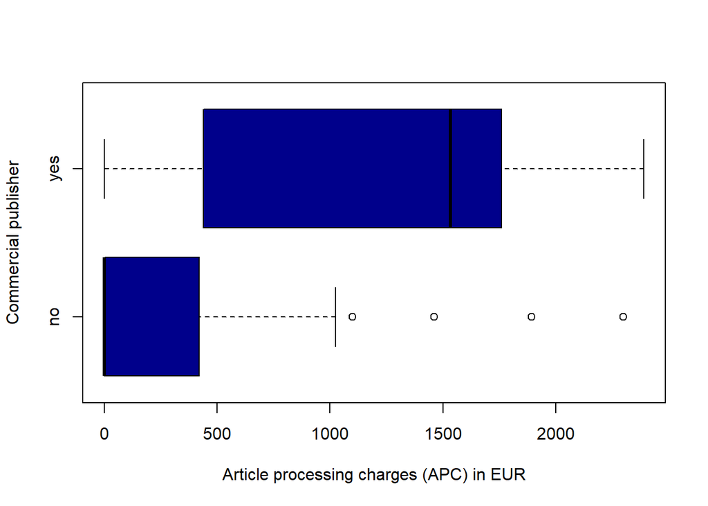

```r
boxplot(APC ~ commercial_publisher,
        data = journals_analysis %>% filter(open_access == "yes"),
        horizontal = TRUE,
        ylab = "Commercial publisher",
        xlab = "Article processing charges (APC) in EUR",
        col = "darkblue"
        )
```

The Mann–Whitney U-test (Wilcoxon’s rank sum test) was applied to test the alternative hypothesis that the APC differed according to publisher commercial status classification:

```r
wil <- wilcox.test(APC ~ commercial_publisher,
                   data = journals_analysis,
                   exact = FALSE
                   )
wil
```

```
    Wilcoxon rank sum test with continuity correction

data:  APC by commercial_publisher
W = 33.5, p-value = 0.0198
alternative hypothesis: true location shift is not equal to 0
```

## Year of conversion to OA

The year of registration of journals as fully open access (OA) is summarized in the following table:

```r
journals_analysis %>%
  filter(open_access == "yes") %>%
  summarize(
    n = n(),
    min = min(OA_since),
    Q1 = quantile(OA_since,0.25),
    median = median(OA_since),
    Q3 = quantile(OA_since,0.75),
    max = max(OA_since)
  ) %>%
  gt %>%
  cols_label(n = "Number of Journals") %>%
  cols_align(
    align = "center",
    columns = everything()
    )
```

| Number of Journals | min | Q1 | median | Q3 | max |
| --- | --- | --- | --- | --- | --- |
| 33 | 1999 | 2011 | 2016 | 2018 | 2024 |

## Author copyright

Out of the 107 publications included for analysis, **n = 15 (14%)** allowed authors to retain the copyright of their works.

## Licensing

The types of licenses allowed in the journals indexed in DOAJ were the following:

```r
journals_analysis %>%
  filter(open_access == "yes") %>%
  mutate(N = length(id)) %>%
  separate_rows(license, sep = ", ") %>%
  group_by(license) %>%
  summarize(n = n(), N = first(N)) %>%
  arrange(desc(n)) %>%
  mutate(Percentage = round((n/N * 100),1)) %>%
  gt %>%
  cols_hide(N)
```

| license | n | Percentage |
| --- | --- | --- |
| CC BY | 19 | 57.6 |
| CC BY-NC-ND | 10 | 30.3 |
| CC BY-NC | 6 | 18.2 |
| CC BY-NC-SA | 3 | 9.1 |
| CC0 | 1 | 3.0 |
| NA | 1 | 3.0 |

# R Package References

```r
report::cite_packages(session)
```

- Grolemund G, Wickham H (2011). “Dates and Times Made Easy with lubridate.” *Journal of Statistical Software*, *40*(3), 1-25. https://www.jstatsoft.org/v40/i03/.
- Iannone R, Cheng J, Schloerke B, Hughes E, Lauer A, Seo J, Brevoort K, Roy O (2024). *gt: Easily Create Presentation-Ready Display Tables*. R package version 0.11.0, https://CRAN.R-project.org/package=gt.
- Makowski D, Lüdecke D, Patil I, Thériault R, Ben-Shachar M, Wiernik B (2023). “Automated Results Reporting as a Practical Tool to Improve Reproducibility and Methodological Best Practices Adoption.” *CRAN*. https://easystats.github.io/report/.
- Müller K, Wickham H (2023). *tibble: Simple Data Frames*. R package version 3.2.1, https://CRAN.R-project.org/package=tibble.
- Ooms J (2014). “The jsonlite Package: A Practical and Consistent Mapping Between JSON Data and R Objects.” *arXiv:1403.2805 [stat.CO]*. https://arxiv.org/abs/1403.2805.
- Ooms J (2024). *writexl: Export Data Frames to Excel ‘xlsx’ Format*. R package version 1.5.1, https://CRAN.R-project.org/package=writexl.
- R Core Team (2024). *R: A Language and Environment for Statistical Computing*. R Foundation for Statistical Computing, Vienna, Austria. https://www.R-project.org/.
- Rinker TW, Kurkiewicz D (2018). *pacman: Package Management for R*. version 0.5.0, http://github.com/trinker/pacman.
- Wickham H (2016). *ggplot2: Elegant Graphics for Data Analysis*. Springer-Verlag New York. ISBN 978-3-319-24277-4, https://ggplot2.tidyverse.org.
- Wickham H (2023). *forcats: Tools for Working with Categorical Variables (Factors)*. R package version 1.0.0, https://CRAN.R-project.org/package=forcats.
- Wickham H (2023). *httr: Tools for Working with URLs and HTTP*. R package version 1.4.7, https://CRAN.R-project.org/package=httr.
- Wickham H (2023). *stringr: Simple, Consistent Wrappers for Common String Operations*. R package version 1.5.1, https://CRAN.R-project.org/package=stringr.
- Wickham H (2024). *rvest: Easily Harvest (Scrape) Web Pages*. R package version 1.0.4, https://CRAN.R-project.org/package=rvest.
- Wickham H, Averick M, Bryan J, Chang W, McGowan LD, François R, Grolemund G, Hayes A, Henry L, Hester J, Kuhn M, Pedersen TL, Miller E, Bache SM, Müller K, Ooms J, Robinson D, Seidel DP, Spinu V, Takahashi K, Vaughan D, Wilke C, Woo K, Yutani H (2019). “Welcome to the tidyverse.” *Journal of Open Source Software*, *4*(43), 1686. doi:10.21105/joss.01686 https://doi.org/10.21105/joss.01686.
- Wickham H, Bryan J (2023). *readxl: Read Excel Files*. R package version 1.4.3, https://CRAN.R-project.org/package=readxl.
- Wickham H, François R, Henry L, Müller K, Vaughan D (2023). *dplyr: A Grammar of Data Manipulation*. R package version 1.1.4, https://CRAN.R-project.org/package=dplyr.
- Wickham H, Henry L (2023). *purrr: Functional Programming Tools*. R package version 1.0.2, https://CRAN.R-project.org/package=purrr.
- Wickham H, Hester J, Bryan J (2024). *readr: Read Rectangular Text Data*. R package version 2.1.5, https://CRAN.R-project.org/package=readr.
- Wickham H, Vaughan D, Girlich M (2024). *tidyr: Tidy Messy Data*. R package version 1.3.1, https://CRAN.R-project.org/package=tidyr.